# Assignment 3 Task 3: Santa Barbara Urchins

Alia Ajina

10/28/2021

# Overview

This code uses version control, project management, data wrangling, analysis, and visualization skills to explore red and purple urchin records from the Santa Barbara Coastal Long Term Ecological Research (SBC LTER) program’s divers. The data is from a long-term experiment on kelp removal and the sea urchin (red and purple) size frequency distribution.

Data Citation: Reed, D. 2020. SBC LTER: Reef: Long-term experiment: Kelp removal: Urchin size frequency distribution ver 20. Environmental Data Initiative. https://doi.org/10.6073/pasta/5a1e9ef03aa47bd2225c0bb98a02a63b.

# Setup

Attach tidyverse, here, janitor, and kableExtra packages.

```r
knitr::opts_chunk$set(echo = TRUE, warning = FALSE, message = FALSE)
library(tidyverse)
library(here)
library(janitor)
library(kableExtra)
library(lubridate)
```

# Section 1

## Read in Urchins data

```r
urchins <- read_csv(here("data", "urchins.csv"))
```

## Data Wrangling

Clean the data

```r
urchins_clean <- urchins %>%
  clean_names()
```

## Data Visualization

Create a finalized, faceted histogram comparing the distribution of sizes between purple and red sea urchins.

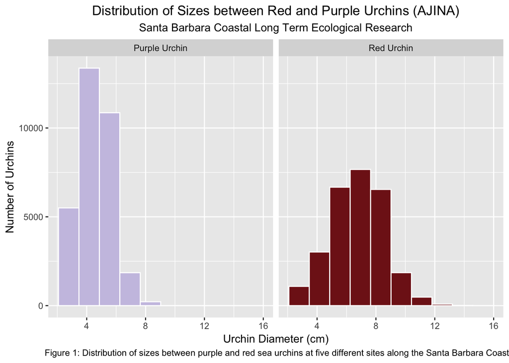

```r
ggplot(data = urchins_clean, aes(x = size)) +
  geom_histogram(aes(fill = common_name, color = common_name), bins = 10) +
  facet_wrap(~ common_name) + # Facet wrap by "common_name"
  scale_color_manual(values = c("white", "white")) +
  scale_fill_manual(values = c("#CBC3E3", "#801B1B")) +
  theme_gray() +
  theme(axis.title.x = element_text(hjust = 0.5, vjust = 0.5),
        plot.title = element_text(hjust = .5),
        plot.subtitle = element_text(hjust = .5),
        plot.caption = element_text(hjust = .3),
        legend.position = "none") +
  labs( x = "Urchin Diameter (cm)",
        y = "Number of Urchins",
        title = "Distribution of Sizes between Red and Purple Urchins (AJINA)",
        subtitle = "Santa Barbara Coastal Long Term Ecological Research",
        caption = "Figure 1: Distribution of sizes between purple and red sea urchins at five different sites along the Santa Barbara Coast.")
```

## Summary Statistics

Summary table of statistics for purple and red urchins including mean, median, standard deviation, and sample size. Use KableExtra to finalize the table.

```r
urchins_summary <- urchins_clean %>%
  group_by(common_name) %>%
  summarize(mean = round(mean(size), 2),
            median = median(size),
            sd = round(sd(size), 1),
            sample_size = n())

# Use KableExtra to finalize the table

urchins_summary %>%
  kable(col.names = c("Common Name",
                      "Mean Size (cm)",
                      "Median Size (cm)",
                      "Standard Deviation (cm)",
                      "Sample Size"),
        caption = "<center>Table 1: Summary Statistics of Purple and Red Urchins<center>") %>%
  kable_styling(bootstrap_options = "bordered",
                full_width = F, position = "center")
```

Table 1: Summary Statistics of Purple and Red Urchins

| Common Name | Mean Size (cm) | Median Size (cm) | Standard Deviation (cm) | Sample Size |
| --- | --- | --- | --- | --- |
| Purple Urchin | 4.47 | 4.5 | 1.2 | 31805 |
| Red Urchin | 6.78 | 7.0 | 1.9 | 27408 |

The summary statistics for red and purple sea urchins allows us to see that red sea urchins are slightly larger than the purple urchins, at 2.3 cm larger on average leading to a 41% difference in mean urchin diameter between the two. The purple sea urchins have a smaller standard deviation and a mean and median that are nearly the same. In comparison to red sea urchins, this concludes that purple sea urchin data has less spread than red sea urchin data.

# Section 2

## Data Wrangling

Create a new subset of data, purple_urchins, convert the date column to the class “Date”, create a new column that only contains the year, and and create another new column called site_full that contains the full name of the five sites, not just their abbreviation.

```r
purple_urchins <- urchins_clean %>%
  filter(common_name == "Purple Urchin") %>%
  mutate(date = mdy(date)) %>%
  mutate(year = year(date)) %>%
  mutate(site_full = case_when(site == "NAPL" ~ "Naples Reef",
                               site == "AQUE" ~ "Arroyo Quemado Reef",
                               site == "CARP" ~ "Carpinteria Reef",
                               site == "MOHK" ~ "Mohawk Reef",
                               site == "IVEE" ~ "Isla Vista Reef"))
```

### Table of Purple Urchins observed by site and year.

```r
total_purple_urchins <- purple_urchins %>%
  group_by(site_full, year) %>%
  summarize(count=n())
```

## Data Visualization

Two finalized graphs of counts of purple urchins recorded at each site over time for the years included in the study visualized in both a bar graph and a line graph for optimal comparison.

### Bar Graph of Purple Urchin Distribution per Year by Site

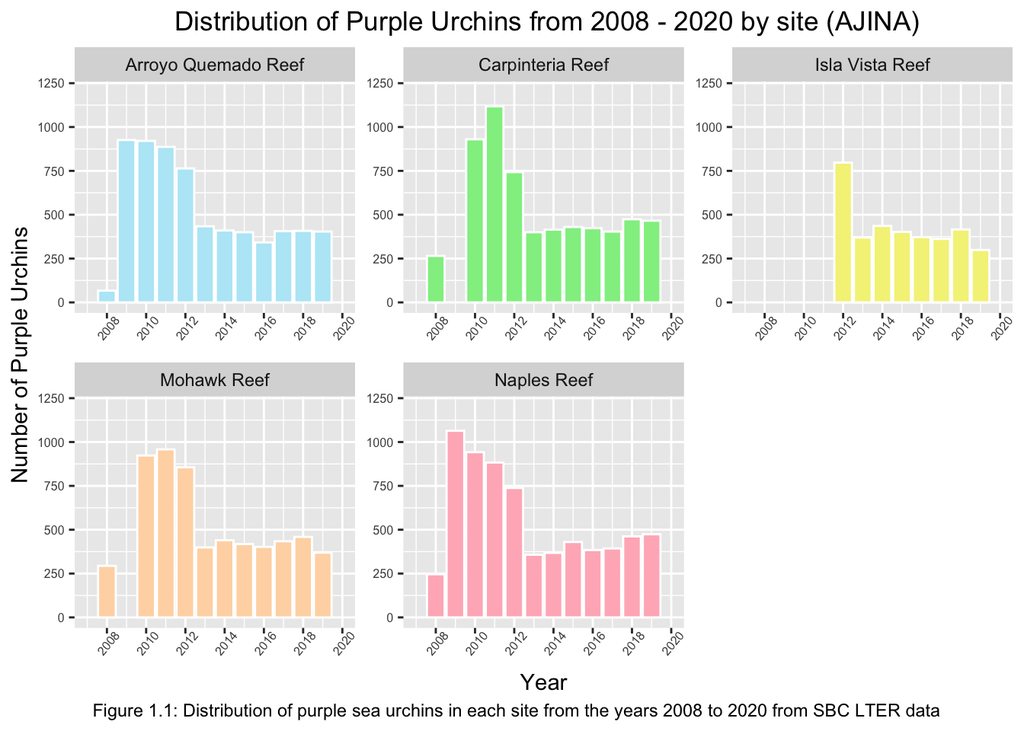

```r
ggplot(data = total_purple_urchins,
       aes(x = year, y = count)) +
  geom_col(aes(color = site_full, fill = site_full)) +
  facet_wrap(~ site_full, scale = 'free') + # Facet wrap by "site_full" and change scale to free in order to have an x and y axis on each individual plot
  scale_color_manual(values = c("white", "white", "white", "white", "white")) +
  scale_fill_manual(values = c("#B7E9F7", "#90EE90", "#F4F186", "#FED8B1", "#FFB6C1")) +
  theme_gray() +
  scale_x_continuous(limits=c(2007,2020), breaks = c(2008, 2010, 2012, 2014, 2016, 2018, 2020)) +
  scale_y_continuous(limits=c(0,1200)) + # Add limits to the scales in order to keep the axis the same
  labs( x = "Year",
        y = "Number of Purple Urchins",
        title = " Distribution of Purple Urchins from 2008 - 2020 by site (AJINA)",
        caption = "Figure 1.1: Distribution of purple sea urchins in each site from the years 2008 to 2020 from SBC LTER data") +
  theme(axis.text.x = element_text(size = 6, hjust = 0.6, angle = 50),
        axis.text.y = element_text(size = 6),
        axis.title.x = element_text(hjust = 0.5,
                                    vjust = 0.5),
        plot.title = element_text(hjust = .5),
        plot.subtitle = element_text(hjust = .5),
        plot.caption = element_text(hjust = .2),
        legend.position = "none")
```

### Line graph of Purple Urchin Distribution per Year by Site

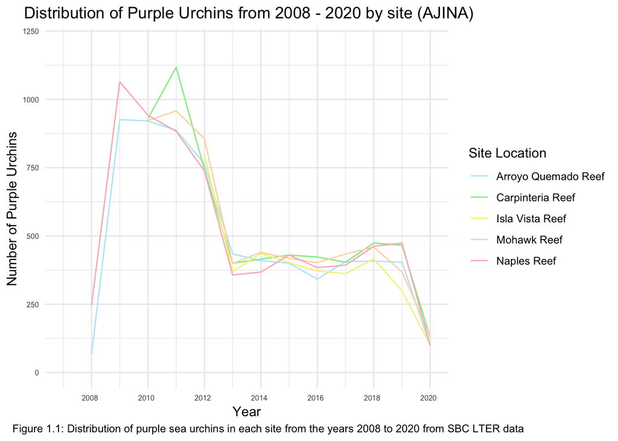

```r
ggplot(data = total_purple_urchins,
       aes(x = year, y = count)) +
  geom_line(aes(color = site_full, scale = 'free')) +
  scale_color_manual(values = c("#B7E9F7", "#90EE90", "#F4F186", "#FED8B1", "#FFB6C1")) +
  theme_minimal() +
  scale_x_continuous(limits=c(2007,2020), breaks = c(2008, 2010, 2012, 2014, 2016, 2018, 2020)) +
  scale_y_continuous(limits = c(0,1200)) +
  labs( x = "Year",
        y = "Number of Purple Urchins",
        title = " Distribution of Purple Urchins from 2008 - 2020 by site (AJINA)",
        caption = "Figure 1.1: Distribution of purple sea urchins in each site from the years 2008 to 2020 from SBC LTER data",
        color = "Site Location",
        Key = "Site") +
  theme(axis.text.x = element_text(size = 6, hjust = 0.6),
        axis.text.y = element_text(size = 6),
        axis.title.x = element_text(hjust = 0.5,
                                    vjust = 0.5),
        plot.title = element_text(hjust = .5),
        plot.subtitle = element_text(hjust = .5),
        plot.caption = element_text(hjust = .3))
```